# Моментум-стратегии и reality check Малайзия (данные с нулями)

> Количество исследумых компаний – **151**

> Период отслеживания менялся от **1** до **12** месяцев

> Период ожидания менялся от **0** до **8** недель

> Период инвестирования менялся от **1** до **12** месяцев

## 1. Моментум стратегии при равных весах. Ранжирование по средней доходности (бенчмарк 6% годовых - только для reality check)

> Всего было рассмотрено **5184** стратегий

#### **Таблица 1. Все стратегии**

|  | mean | t | p-value | hist_per | moment_per | invest_per | percent | Amount_of_negative |
| --- | --- | --- | --- | --- | --- | --- | --- | --- |
| 1 | 0.003703 | 3.817531 | 0.000149 | 4 | 0 | 4 | 0.5 | 254 |
| 2 | 0.00414 | 6.101577 | 0 | 4 | 0 | 8 | 0.5 | 215 |
| 3 | 0.005135 | 9.071273 | 0 | 4 | 0 | 12 | 0.5 | 188 |
| 4 | 0.00484 | 9.826472 | 0 | 4 | 0 | 16 | 0.5 | 190 |
| 5 | 0.004316 | 9.330916 | 0 | 4 | 0 | 20 | 0.5 | 176 |
| 6 | 0.004251 | 9.628565 | 0 | 4 | 0 | 24 | 0.5 | 181 |
| 7 | 0.004036 | 9.449536 | 0 | 4 | 0 | 28 | 0.5 | 176 |
| 8 | 0.003859 | 8.921831 | 0 | 4 | 0 | 32 | 0.5 | 180 |
| 9 | 0.003873 | 9.131029 | 0 | 4 | 0 | 36 | 0.5 | 188 |
| 10 | 0.004007 | 9.617736 | 0 | 4 | 0 | 40 | 0.5 | 176 |

[output cut: 5174 more lines]

#### **Рисунок 1.**

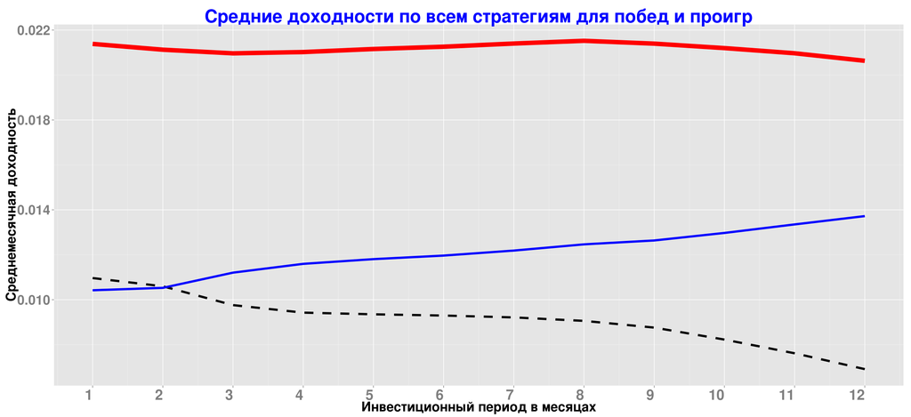

#### **Таблица 2. Агрегированные по всем стратегиям доходности победителей и проигравших**

|  | invest.per | aggr.winner | aggr.loser | delta |
| --- | --- | --- | --- | --- |
| 1 | 1 | 0.0214 | 0.0104 | 0.011 |
| 2 | 2 | 0.0211 | 0.0105 | 0.0106 |
| 3 | 3 | 0.021 | 0.0112 | 0.0098 |
| 4 | 4 | 0.021 | 0.0116 | 0.0094 |
| 5 | 5 | 0.0212 | 0.0118 | 0.0094 |
| 6 | 6 | 0.0213 | 0.012 | 0.0093 |
| 7 | 7 | 0.0214 | 0.0122 | 0.0092 |
| 8 | 8 | 0.0215 | 0.0125 | 0.0091 |
| 9 | 9 | 0.0214 | 0.0126 | 0.0088 |
| 10 | 10 | 0.0212 | 0.013 | 0.0082 |

[output cut: 2 more lines]

> Лучшая по средней доходности стратегия дает среднемесячную доходность **2.02** **%** и имеет параметры: период отбора – **4** месяцев, период ожидания – **1** недель, период инвестирования – **1** месяцев, процентиль – **0.1**

> Bootstrap p-value равен **0.016**

> Всего портфелей у лучшей стратегии – **585** Количество отрицательных доходностей у лучшей стратегии – **199** ( **34.02%** )

#### **Рисунок 2.**

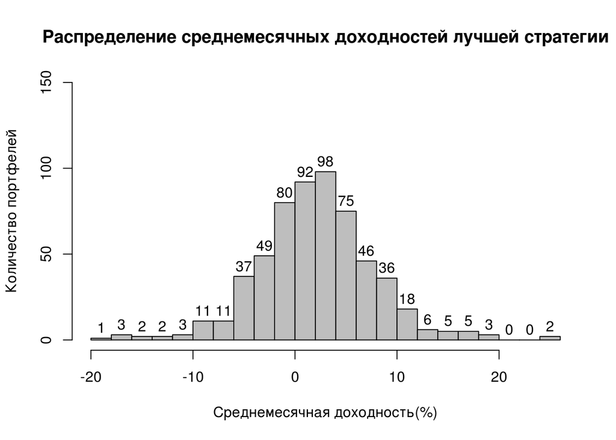

#### **Рисунок 3. (вертикальные пунктирные линии - начало нового года)**

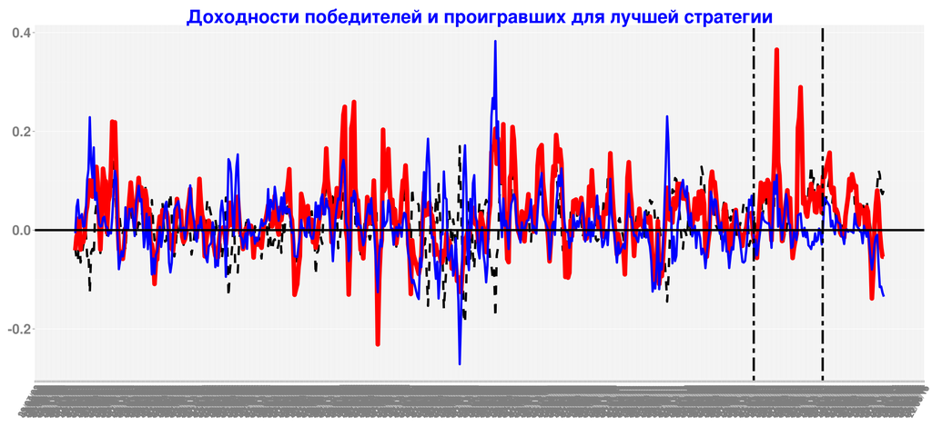

#### **Таблица 3. Доходности победителей и проигравших для лучшей стратегии**

|  | date | Win_portf | Los_portf | Win_Los |
| --- | --- | --- | --- | --- |
| 1 | 2003-02-28 | -0.041 | -0.0063 | -0.0347 |
| 2 | 2003-03-07 | -0.0131 | 0.047 | -0.0601 |
| 3 | 2003-03-14 | -0.0031 | 0.0616 | -0.0647 |
| 4 | 2003-03-21 | 0.0243 | 0.0242 | 0.0001 |
| 5 | 2003-03-28 | -0.0393 | 0.0263 | -0.0656 |
| 6 | 2003-04-04 | -0.017 | 0.0326 | -0.0496 |
| 7 | 2003-04-11 | -0.0242 | 0.007 | -0.0313 |
| 8 | 2003-04-18 | -0.0111 | 0.0081 | -0.0191 |
| 9 | 2003-04-25 | 0.0333 | 0.0364 | -0.0031 |
| 10 | 2003-05-02 | 0.0486 | 0.1017 | -0.0531 |

[output cut: 575 more lines]

### **Вхождение в победителей и проигравших для лучшей стратегии**

#### **Рисунок 4.**

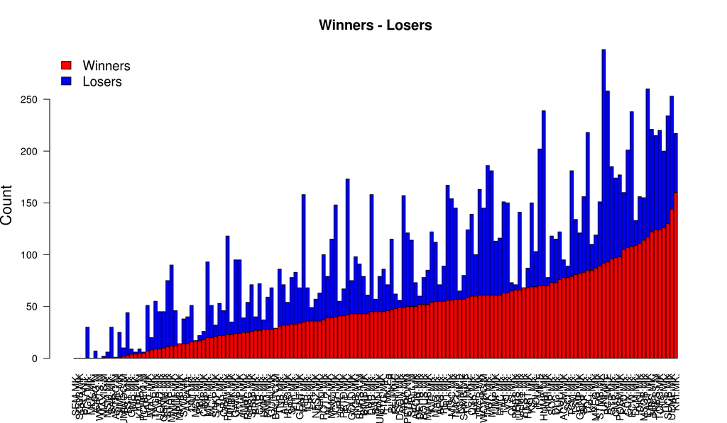

#### **Рисунок 5.**

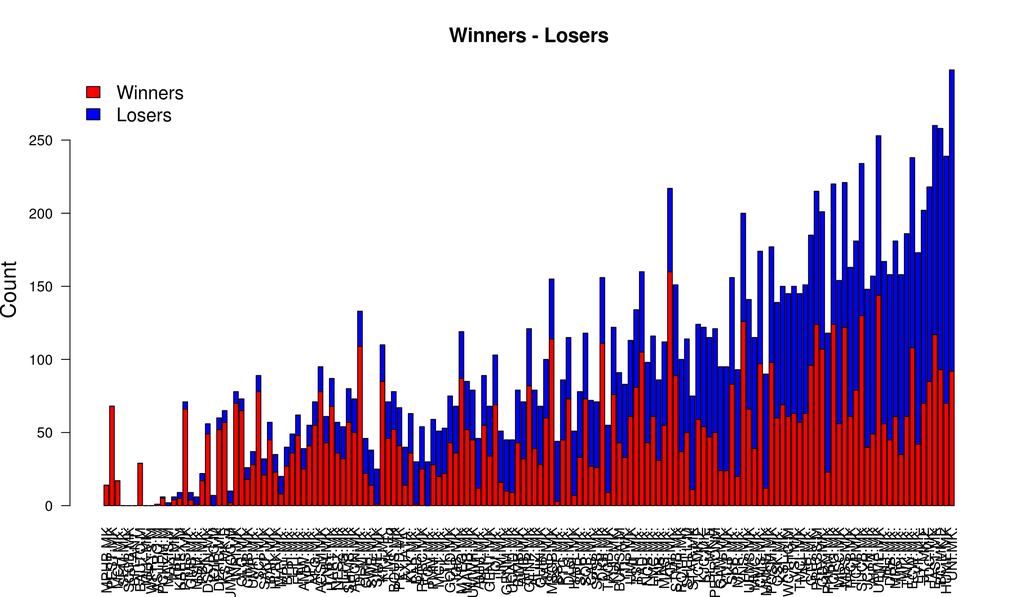

#### **Таблица 4. Вхождение компаний в победители и проигравшие для лучшей по средней доходности стратегии**

|  | Ticket | In_winners | In_losers |
| --- | --- | --- | --- |
| 1 | FEH.MK.Equity | 48 | 14 |
| 2 | MPHB.MK.Equity | 14 | 0 |
| 3 | PETRONM.MK.Equity | 50 | 71 |
| 4 | JT.MK.Equity | 70 | 132 |
| 5 | DEHB.MK.Equity | 52 | 8 |
| 6 | TMCL.MK.Equity | 57 | 88 |
| 7 | UMR.MK.Equity | 28 | 9 |
| 8 | PAD.MK.Equity | 105 | 55 |
| 9 | PEST.MK.Equity | 68 | 0 |
| 10 | GOLD.MK.Equity | 43 | 32 |

[output cut: 141 more lines]

## 2. Моментум стратегии при равных весах. Ранжирование по t-статистике (бенчмарк 6% годовых - только для reality check)

> Лучшая по t-статистике стратегия дает среднемесячную доходность **1.16** **%** и имеет параметры: период отбора – **3** месяцев, период ожидания – **1** недель, период инвестирования – **3** месяцев, процентиль – **0.3**

> Bootstrap p-value равен **0.062**

> Всего портфелей у лучшей по t-статистике стратегии – **585** Количество отрицательных доходностей у лучшей по t-статистике стратегии – **124** ( **21.2%** )

#### **Рисунок 6.**

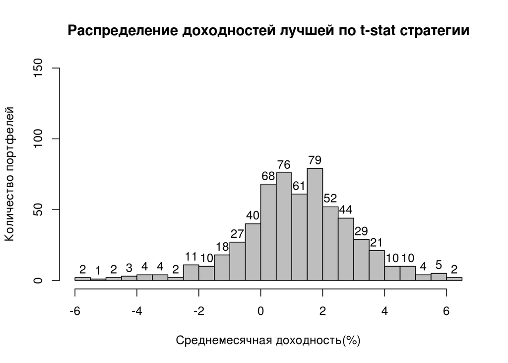

#### **Рисунок 7. (вертикальные пунктирные линии - начало нового года)**

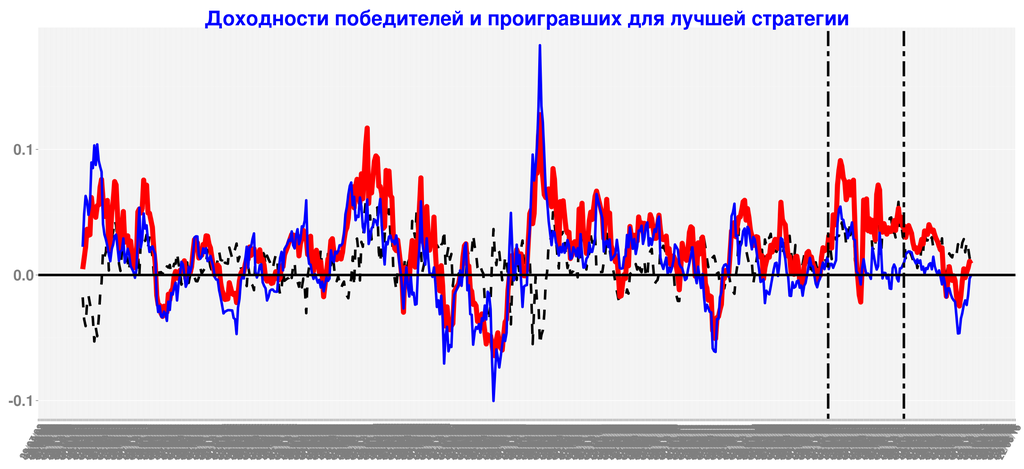

#### **Таблица 5. Доходности победителей и проигравших для лучшей стратегии**

|  | date | Win_portf | Los_portf | Win_Los |
| --- | --- | --- | --- | --- |
| 1 | 2003-02-28 | 0.0047 | 0.0225 | -0.0178 |
| 2 | 2003-03-07 | 0.0133 | 0.0485 | -0.0352 |
| 3 | 2003-03-14 | 0.0223 | 0.063 | -0.0407 |
| 4 | 2003-03-21 | 0.0364 | 0.0588 | -0.0224 |
| 5 | 2003-03-28 | 0.0316 | 0.0479 | -0.0163 |
| 6 | 2003-04-04 | 0.0321 | 0.0551 | -0.023 |
| 7 | 2003-04-11 | 0.0617 | 0.0896 | -0.0279 |
| 8 | 2003-04-18 | 0.0506 | 0.0851 | -0.0345 |
| 9 | 2003-04-25 | 0.0503 | 0.1032 | -0.0529 |
| 10 | 2003-05-02 | 0.046 | 0.0876 | -0.0417 |

[output cut: 575 more lines]

### **Вхождение в победителей и проигравших для лучшей стратегии**

#### **Рисунок 8.**

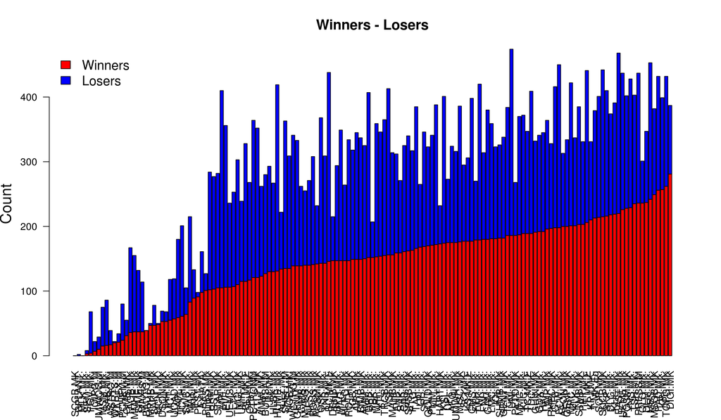

#### **Рисунок 9.**

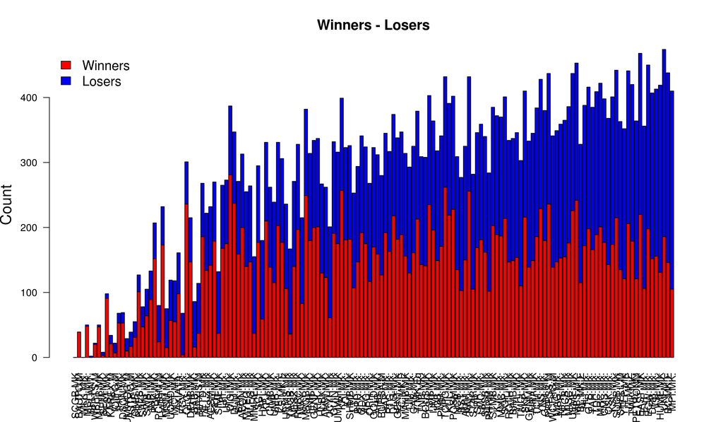

#### **Таблица 6. Вхождение компаний в победители и проигравшие для лучшей по t-статистике стратегии**

|  | Ticket | In_winners | In_losers |
| --- | --- | --- | --- |
| 1 | FEH.MK.Equity | 179 | 91 |
| 2 | MPHB.MK.Equity | 47 | 3 |
| 3 | PETRONM.MK.Equity | 121 | 243 |
| 4 | JT.MK.Equity | 206 | 235 |
| 5 | DEHB.MK.Equity | 147 | 68 |
| 6 | TMCL.MK.Equity | 110 | 193 |
| 7 | UMR.MK.Equity | 115 | 124 |
| 8 | PAD.MK.Equity | 256 | 176 |
| 9 | PEST.MK.Equity | 91 | 7 |
| 10 | GOLD.MK.Equity | 170 | 153 |

[output cut: 141 more lines]